# Ngme2 - A Flexible R Package for Latent non-Gaussian Models

2023-01-23

## Introduction

`ngme2` is the updated version of R package `ngme` (https://github.com/davidbolin/ngme).

`ngme2` is an R package that contains functions for **inference and prediction** for **Gaussian and non-Gaussian** latent models.

The package has support for linear mixed effects models, spatial random field models…

It is an ongoing work with **David Bolin**, **Alexandre B. Simas**, and **Jonas Wallin**.

Installation:

`remotes::install_github("davidbolin/ngme2", ref = "devel")`

## Model Framework

The package `ngme2` provides methods for mixed effect models:

\[ \begin{aligned} Y = {\bf X}^{\top} {\bf \beta} + \sum_j {\bf A}_j W_j({\bf t}) + \epsilon. \end{aligned} \]

- \(Y\) is the response variable,
- \({\bf X}\) is the matrix of fixed effects explanatory variables,
- \({\bf \beta}\) is the matrix of fixed effects coefficients,
- \({\bf A}_j\) is the observation matrix for each process,
- \(W_j(t)\) is specified as a stochastic process,
- \(\epsilon\) is measurement error.

## Features

1. Support spatial models like Matern model with non-Gaussian noise.
2. Support models for temporal data like **AR1** and **random walk** of order 1 and 2.
3. Support replicate at same locations.
4. Support non-Gaussian measurement noise.
5. Support prediction at unknown locations.
6. Comparing to the previous version, it now supports multiple stochastic processes in the latent model.

## Non-Gaussian Model

In order to model departures from Gaussian behaviour we will consider the following extension due to [Bolin (2014)]: \[(\kappa^2 - \Delta)^\beta X(\mathbf{s}) = \dot{\mathcal{M}}(\mathbf{s}),\quad \mathbf{s}\in\mathcal{D},\] where \(\dot{\mathcal{M}}\) is a type-G Lévy process. Its increments can be represented as location-scale mixtures: \[\gamma + \mu V + \sigma \sqrt{V}Z,\] where \(\gamma, \mu, \sigma\) are parameters, \(Z\sim N(0,1)\) and is independent of \(V\), and \(V\) is a positive infinitely divisible random variable. It results in the following form, where \(K\) is the operator part:

\[ KW|V \sim N(\gamma + \mu V, \sigma^2 \, diag(V)), \] also, \(\mu\) and \(\sigma\) can be non-stationary.

## Parameter Estimation

- Ngme2 does maximum likelihood estimation through preconditioned stochastic gradient descent.

The gradient can be approximated by:

\[\nabla_{\boldsymbol{\theta}} L({\boldsymbol{\theta}}; \mathbf{Y}) = E_{\mathbf{V},\mathbf{w}}[\nabla_{\boldsymbol{\theta}} L({\boldsymbol{\theta}}; \mathbf{Y}, \mathbf{V}, \mathbf{w})|\mathbf{Y}].\]

- Multiple chains are run in parallel for better convergence checks.

## R interface

### 1. ngme_noise

```r
 # generalized asymmetric Laplace (GAL) noise
noise_gal(mu = 1, sigma = 2, nu = 1)

# non-stationary nig noise
noise_nig(
  B_mu = cbind(1, 1:5),
  theta_mu = c(1, 2),
  B_sigma = cbind(1, 2:6),
  theta_sigma = c(1,2),
  nu = 1)
```

The 2nd example is the non-stationary NIG noise, where \(\mu = \bf B_{\mu} \bf \theta_{\mu}\), and \(\sigma = \exp(\bf B_{\sigma} \bf \theta_{\sigma})\).

### 2. Specifying latent models with formula

We can have multiple latent model simultaneously:

```r
formula <- Y ~ x1 + f(
    x2,
    model = "ar1",
    noise = noise_gal(mu = 1, sigma = 2, nu = 1),
    alpha = 0.5
  ) + f(
    model = model_rw(1:5, order=1, circular = TRUE),
    noise = noise_normal()
  )
```

### 3. Estimation using ngme2

```r
ngme(
  formula = formula,
  family = noise_normal(sigma = 0.5), # or just "normal"
  data = data.frame(Y = 1:5, x1 = 2:6, x2 = 3:7),
  control = control_opt(
    estimation = FALSE,
    burnin = 100,
    iterations = 1000,
    n_parallel_chain = 4
  )
)
```

## The AR(1) Example

An **autoregressive model of order 1 (AR(1))** specifies that the output variable depends linearly on its own previous values and on a stochastic term. The simplest AR model is an AR(1) model, which is given by: \[ \begin{align} X_1 &= \epsilon_1, \;\;\;\; X_i = \alpha X_{i-1} + \epsilon_i, \; i = 2, \dots , n, \end{align} \]

where \(|\alpha| < 1\), \(\epsilon_1, ..,\epsilon_n\) can be **Gaussian**, **NIG**, and **GAL** noise.

It is easy to verify that \[ K{\bf X} = \boldsymbol\epsilon,\] where \({\bf X} = (X_1, \dots, X_n)\), \({\boldsymbol \epsilon} = (\epsilon_1, \dots, \epsilon_n)\), and \[ K = \begin{bmatrix} 1 \\ -\alpha & 1 \\ & \ddots & \ddots \\ & & -\alpha & 1 \end{bmatrix}. \]

## The AR(1) Example - Simulation

```r
n_obs <- 500
sigma_eps <- 0.5
alpha <- 0.5; mu = -2; delta = -mu; sigma <- 3; nu <- 1

# First we generate the NIG noise
trueV <- ngme2::rig(n_obs, nu, nu, seed = 10)
noise <- delta + mu*trueV + sigma * sqrt(trueV) * rnorm(n_obs)

trueW <- Reduce(function(x,y){y + alpha*x}, noise, accumulate = T)
Y = trueW + rnorm(n_obs, mean=0, sd=sigma_eps)

# Add some fixed effects
x1 = runif(n_obs); x2 = rexp(n_obs)
beta <- c(-3, -1, 2)
X <- (model.matrix(Y ~ x1 + x2))  # design matrix
Y = as.numeric(Y + X %*% beta)
```

## The AR(1) Example - Estimation

```r
ngme_fit <- ngme(
  Y ~ x1 + x2 + f(1:n_obs,
    name = "ar1",
    model = "ar1",
    noise = noise_nig(),
    theta_K = 0.9  # starting point for AR parameter
  ),
  data = data.frame(x1=x1, x2=x2, Y=Y),
  control = control_opt(
    burnin = 100,
    iterations = 1000,
    n_gibbs_samples = 5,
    n_parallel_chain = 4,
    print_check_info = FALSE
  ),
  seed = 3
)
```

### Use `traceplot()` to see the trajectory of estimation

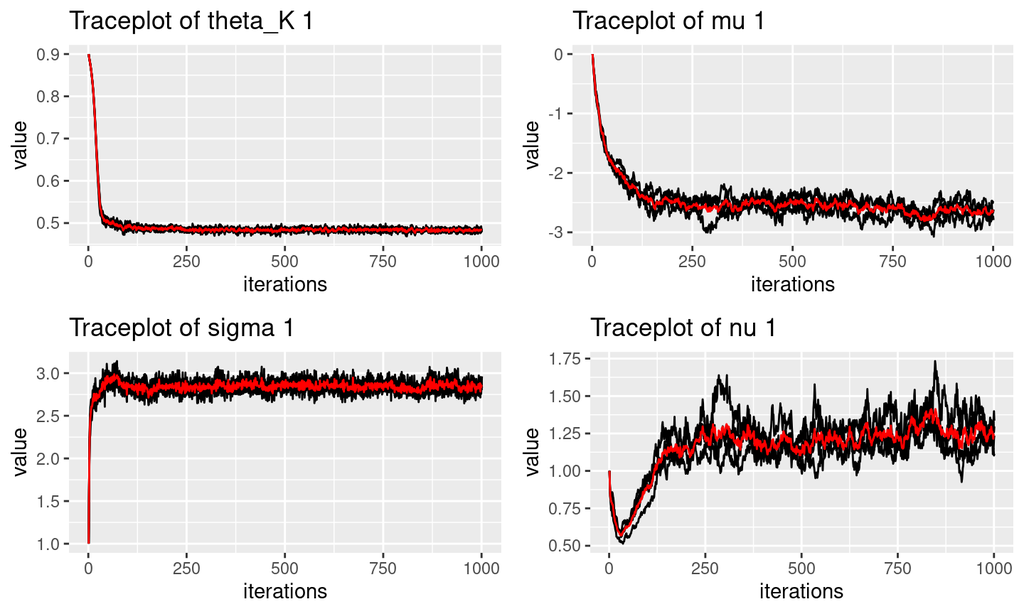

```r
traceplot(ngme_fit, "ar1")
```

## Real data analysis

The rainfall data from Paraná (Brazil) is collected by the National Water Agency in Brazil (Agencia Nacional de Águas, ANA, in Portuguese).

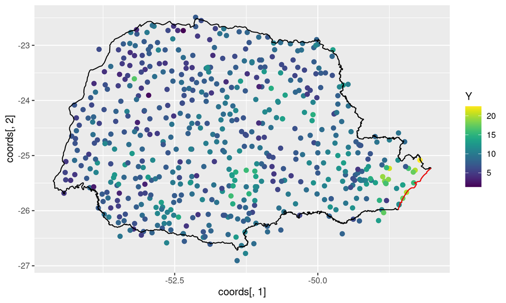

### Compare different models

```r
matern_spde <- model_matern(loc = coords, mesh = prmesh)
fm0 <- Y ~ 1 +
  f(inla.group(seaDist), model = "rw1", noise = noise_normal()) +
  f(model = matern_spde, noise = noise_normal())
fm1 <- Y ~ 1 +
  f(inla.group(seaDist), model = "rw1", noise = noise_normal()) +
  f(model = matern_spde, noise = noise_nig())
fm2 <- Y ~ 1 +
  f(inla.group(seaDist), model = "rw1", noise = noise_normal()) +
  f(model = matern_spde, noise = noise_normal()) +
  f(model = matern_spde, noise = noise_nig())
fm3 <- Y ~ 1 +
  f(inla.group(seaDist), model = "rw1", noise = noise_normal()) +
  f(model = matern_spde, noise = noise_normal_nig())
```

## Model validation

Cross validation usage:

```r
cross_validation(ngme_fit, type="k-fold", k=5)
```

Results of cross validation (2000 iterations for each model):

```r
df <- as.data.frame(rbind(cv0, cv1, cv2, cv3))
rownames(df) <- c("normal","NIG",
  "normal+NIG(diff k)",
  "normal+NIG(same k)"
)
format(df, digits=3)
```

```
##                     MAE  MSE   CRPS sCRPS
## normal             2.15 7.33  -1.07 -1.44
## NIG                2.05 6.63  -1.02 -1.42
## normal+NIG(diff k) 1.96 6.07 -0.974 -1.39
## normal+NIG(same k) 2.09 6.89  -1.04 -1.44
```

## Prediction

Prediction using RW1 + SPDE_NIG + SPDE_normal model using `predict(ngme_fit, loc=new_loc)`:

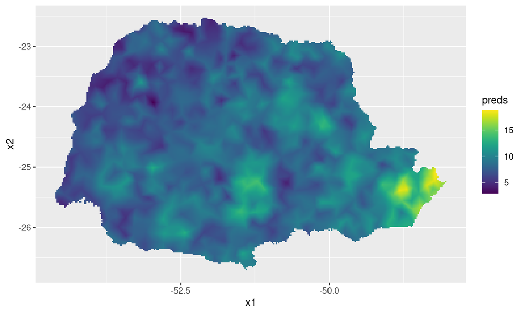

## Future work

- Support specifying priors
- Multivariate model
- Random effects
- Confidence intervals for estimators
- Rational approximations

## Main references

Bolin, D. (2014). Spatial Matérn Fields Driven by Non-Gaussian Noise: Non-Gaussian spatial Matérn fields. Scandinavian Journal of Statistics, 41(3), 557–579. https://doi.org/10.1111/sjos.12046

Asar, Ö., Bolin, D., Diggle, P. J., & Wallin, J. (2020). Linear mixed effects models for non‐Gaussian continuous repeated measurement data. Journal of the Royal Statistical Society: Series C (Applied Statistics), 69(5), 1015–1065. https://doi.org/10.1111/rssc.12405

## Further more

Group homepage: https://cemse.kaust.edu.sa/stochproc

Package homepage: https://davidbolin.github.io/ngme2

Github repository: https://github.com/davidbolin/ngme2

## Thank you!

Stochastic Processes and Applied Statistics @ KAUST